# All figures for manuscript

### Define personal theme to use for all plots

Adapted from tutorial: [Harvard Chan Bioinformatics Core (HBC) with CC BY 4.0](https://hbctraining.github.io/publication_perfect/)

Cowplot white background adapted from [here](https://stackoverflow.com/questions/53370824/change-background-color-with-plot-grid)

```r
cm_to_inch <- function(value_cm) {
  return(value_cm / 2.54)
}
page_width <- 18 # 18 cm
page_height <- 18 # 18 cm
figure_label_size <- 10
text_size <- 6

# specify the font sizes in functions and add white background
plot_grid <- function(...) {
  cowplot::plot_grid(..., label_size = figure_label_size) +
    ggplot2::theme(plot.background = ggplot2::element_rect(fill = "white", color = "white"))
}
annotate <- function(...) {
  # see https://ggplot2-book.org/annotations#sec-custom-annotations for more details
  # on going from mm to points
  ggplot2::annotate(..., size = text_size * 25.4 / 72.27)
}

geom_text <- function(...) {
  ggplot2::geom_text(..., size = text_size * 25.4 / 72.27)
}

columnAnnotation <- function(..., annotation_legend_param = list()) {
  ComplexHeatmap::columnAnnotation(...,
    annotation_name_gp = gpar(fontsize = text_size, fontface = 2),
    annotation_legend_param = c(annotation_legend_param, list(
      title_gp = gpar(fontsize = text_size, fontface = 2),
      labels_gp = gpar(fontsize = text_size)
    ))
  )
}
rowAnnotation <- function(..., annotation_legend_param = list()) {
  ComplexHeatmap::rowAnnotation(...,
    annotation_name_gp = gpar(fontsize = text_size, fontface = 2),
    annotation_legend_param = c(annotation_legend_param, list(
      title_gp = gpar(fontsize = text_size, fontface = 2),
      labels_gp = gpar(fontsize = text_size)
    ))
  )
}
Heatmap <- function(..., heatmap_legend_param = list()) {
  ComplexHeatmap::Heatmap(...,
    row_names_gp = gpar(fontsize = text_size),
    column_names_gp = gpar(fontsize = text_size),
    heatmap_legend_param = c(
      heatmap_legend_param,
      list(
        title_gp = grid::gpar(fontsize = text_size, fontface = 2),
        labels_gp = grid::gpar(fontsize = text_size)
      )
    )
  )
}

# use the same font size for all ggplots
ggplot <- function(...) {
  ggplot2::ggplot(...) +
    theme_half_open(font_size = text_size) +
    # White background and change all font sizes
    theme(
      plot.background = element_rect(fill = "white", color = NA),
      legend.text = element_text(size = text_size),
      legend.title = element_text(size = text_size)
    ) +
    theme(legend.position = "none")
}
```

### Extract legends from plots

The cowplot get_legend has a small bug and this is a workaround. Based on [get_plot_component](https://github.com/wilkelab/cowplot/issues/202).

```r
get_legend <- function(p, position = "bottom", n_row = 1, justification = "center") {
  the_legend <- get_plot_component(
    p +
      guides(
        color = guide_legend(),
        shape = FALSE
      ) +
      guides(color = guide_legend(nrow = n_row)) +
      theme(
        plot.background = element_rect(fill = "white", color = NA),
        legend.text = element_text(size = text_size),
        legend.title = element_text(size = text_size)
      ) +
      theme(
        legend.position = position,
        legend.justification = justification
      ),
    str_glue("guide-box-{position}")
  )
  return(the_legend)
}
```

### Save plots as png, svg, eps, tiff and pdf

Using the cowplot save_plot function but with multiple file types.

```r
save_as_png_svg_pdf <- function(figure_name, plot_object, base_height = page_height, base_width = page_width) {
  base_height_inch <- cm_to_inch(base_height)
  base_width_inch <- cm_to_inch(base_width)
  for (file_extension in c(".svg", ".png", ".pdf", ".eps", ".tiff")){
    save_plot(
      here(output_dir, str_c(figure_name, file_extension)),
      plot_object,
      base_height = base_height_inch,
      base_width = base_width_inch, dpi = 800
    )
  }
  print(here(output_dir, str_c(figure_name, file_extension)))
}
```

## Figures

### Figure 1

#### Load data

```r
lipid_genes_log2_FC1_padj_0.01 <- read_csv(here(data_dir, "lipid_genes_log2_FC1_padj_0.01.csv")) %>%
  column_to_rownames("gene_symbol")
GO_terms_annotation <- read_csv(here(data_dir, "GO_terms_annotation.csv")) %>%
  column_to_rownames("gene_symbol") %>%
  # rename to get the names shorter
  rename_with(~ str_replace(., "metabolic process", "m.p."))
```

#### Prepare metadata

on cell lines for the heatmap

```r
metadata_heatmap_cells <- metadata %>%
  dplyr::select(group, Morphology, Subtype, EMT_score) %>%
  filter(group %in% colnames(lipid_genes_log2_FC1_padj_0.01)) %>%
  column_to_rownames("group")
dim(metadata_heatmap_cells)
```

```
[1] 50  3
```

```r
head(metadata_heatmap_cells)
```

|  | Morphology | Subtype | EMT_score |
| --- | --- | --- | --- |
| BT20 | Epithelial-like | BasalA | -1.33 |
| BT483 | Epithelial-like | Luminal | -3.22 |
| BT549 | Mesenchymal-like | BasalB | 10.60 |
| CAMA-1 | Unknown | Luminal | -2.74 |
| DU4475 | Suspension | BasalA | -0.36 |
| EVSA-T | Epithelial-like | Luminal | -3.45 |

#### Define heatmap colors

```r
ann_colors <- list(
  Morphology = color_legend_cell_lines[unique(metadata_heatmap_cells$Morphology)] %>% unlist(),
  Subtype = color_legend_Subtype,
  "EMT score" = colorRamp2(
    c(
      min(metadata_heatmap_cells$EMT_score),
      max(metadata_heatmap_cells$EMT_score)
    ),
    c(
      color_legend_cell_lines$`Epithelial-like`,
      color_legend_cell_lines$`Mesenchymal-like`
    )
  )
)

GO_colors <- setNames(
  lapply(colnames(GO_terms_annotation), function(x) c("0" = "white", "1" = "black")),
  colnames(GO_terms_annotation)
)

ann_colors
```

[output not shown]

#### Plot

```r
# sort the columns
lipid_genes_log2_FC1_padj_0.01 <- lipid_genes_log2_FC1_padj_0.01 %>%
  dplyr::select(all_of(rownames(metadata_heatmap_cells)))
stopifnot(all(rownames(metadata_heatmap_cells) == colnames(lipid_genes_log2_FC1_padj_0.01)))
```

Use scaled gene expression:

```r
df_heatmap <- lipid_genes_log2_FC1_padj_0.01 %>%
  t() %>%
  scale() %>%
  t()
```

```r
seq <- seq(-2, 2, 0.01)
color_heatmap <- colorRamp2(
  breaks = seq,
  colors = colorRampPalette(c("darkblue", "white", "firebrick"))(length(seq))
)

column_annotation <- columnAnnotation(
  Morphology = metadata_heatmap_cells$Morphology,
  Subtype = metadata_heatmap_cells$Subtype,
  "EMT score" = metadata_heatmap_cells$EMT_score,
  col = ann_colors,
  simple_anno_size = unit(3, "mm")
)
```

```r
# highlight subset of genes
gene_selection <- c(
  # Highlight a few genes

  # phospholipid metabolism
  "PGAP3", # attaching a GPI anchor to proteins
  "PGAP4", # attaching a GPI anchor to proteins

  "ETNK2", # ethanolamine kinase 2
  "DGKG", # diacylglycerol kinase gamma
  "PLPP4", # phospholipid phosphatase 4
  "PLPP5", # phospholipid phosphatase 5

  # Phosphatidylinositol-related
  "PIK3C2B",
  "PIK3CD",
  "PIK3R1",
  "PIK3R3",

  # fatty acid metabolism
  "FASN", # fatty acid synthesis
  "SCD", # MUFA synthesis
  "SREBF1", # sterol regulatory element-binding protein 1, lipid-related transcription factor
  "ACSL4", # Long-chain-fatty-acid--CoA ligase
  "ACSL1", # Long-chain-fatty-acid--CoA ligase

  # lipid transport
  "ABCA12", #   glucosylceramide transporter
  "ABCA3", #   phospholipid transporter
  "ABCG1", #   cholesterol efflux
  "SLC44A2", #   choline transporter in mitochondria
  "SLC44A4", #   Choline transporter-like protein 4
  "ABCB4", #   phospholipid transporter
  "PLTP", #   phospholipid transporter

  # sphingolipid metabolism
  "DEGS2",
  "CERS6",
  "ACER1",
  "GM2A",
  "ASAH1",
  "SMPD3",
  #
  # The estrogen receptor
  "ESR1"
)
gene_indices <- which(rownames(df_heatmap) %in% gene_selection)
gene_indices
```

```
 [1]   1   2   3   4  12  17  28  31  35  36  39  61  64  69  70  71  74  80  89
[20] 102 116 120 121 125 132 144 145 148 161
```

```r
rownames(df_heatmap)[gene_indices]
```

```
 [1] "DEGS2"   "SLC44A4" "SMPD3"   "PGAP3"   "ABCB4"   "ABCA3"   "PGAP4"
 [8] "PIK3CD"  "CERS6"   "ESR1"    "FASN"    "DGKG"    "ABCA12"  "ACER1"
[15] "SREBF1"  "ACSL4"   "PLTP"    "ASAH1"   "PIK3R1"  "PLPP5"   "GM2A"
[22] "PIK3R3"  "ACSL1"   "SLC44A2" "ABCG1"   "PLPP4"   "PIK3C2B" "ETNK2"
[29] "SCD"
```

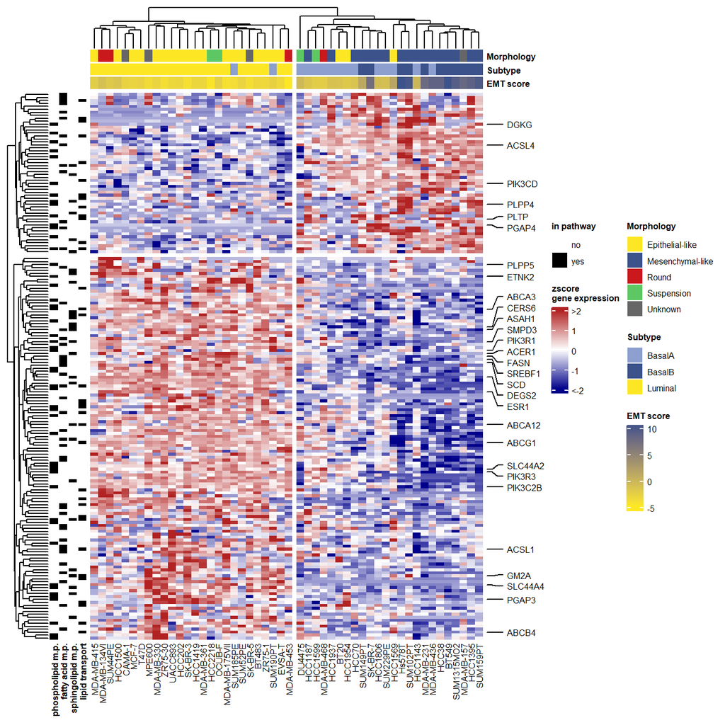

```r
gene_selection_rows <- rowAnnotation(
  link = anno_mark(
    at = gene_indices,
    labels = rownames(df_heatmap)[gene_indices],
    labels_gp = gpar(fontsize = text_size),
    padding = unit(1, "mm")
  )
)

# Add pathways to the left

GO <- rowAnnotation(
  df = GO_terms_annotation,
  col = GO_colors,
  show_legend = c(T, F, F, F),
  annotation_legend_param = list(
    title = "in pathway",
    labels = c("no", "yes")
  ),
  simple_anno_size = unit(2, "mm")
)

figure_1 <- Heatmap(
  matrix = df_heatmap,
  col = color_heatmap,
  heatmap_legend_param = list(
    title = "zscore\ngene expression",
    direction = "vertical",
    at = c(-2, -1, 0, 1, 2),
    labels = c("<-2", -1, 0, 1, ">2"),
    break_dist = c(1, 1, 1, 1)
  ),
  top_annotation = column_annotation,
  # split in two groups for visibility
  column_gap = unit(1, "mm"),
  column_split = 2,
  column_title = NULL,
  row_split = 2,
  row_title = NULL,
  row_gap = unit(1, "mm"),
  # gene names
  show_row_names = F,
  right_annotation = gene_selection_rows,
  # pathways on the left
  left_annotation = GO
)
figure_1
```

#### Save figure

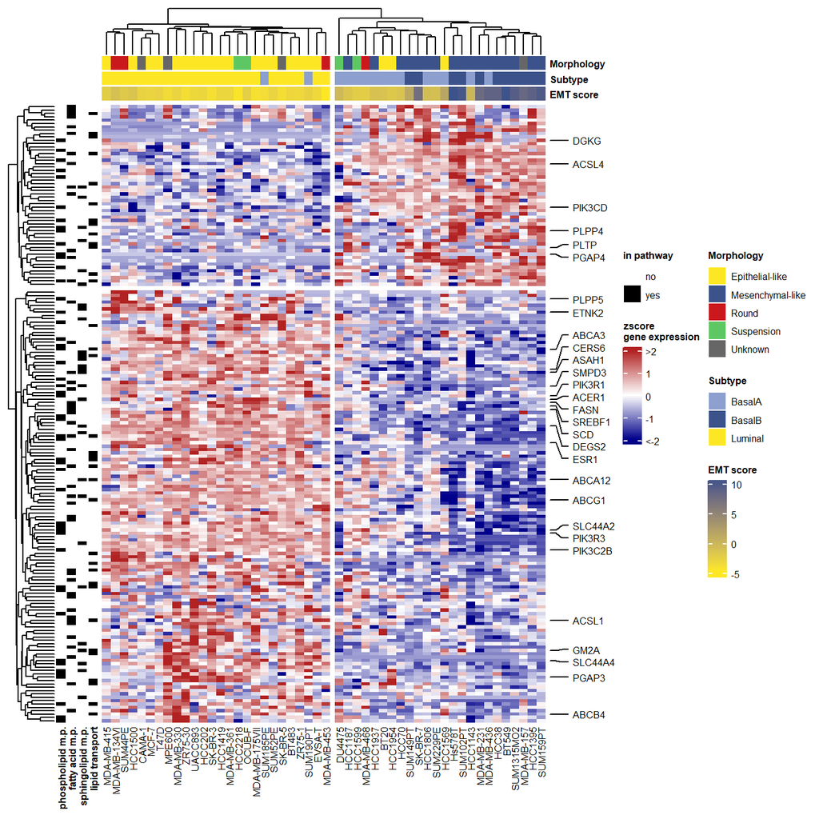

```r
figure_1
```

```r
png(
  filename = here(output_dir, "Figure_1.png"),
  width = page_width, height = page_height, units = "cm", res = 600
)
draw(figure_1)
dev.off()
```

```r
pdf(
  file = here(output_dir, "Figure_1.pdf"),
  width = cm_to_inch(page_width), height = cm_to_inch(18)
)
draw(figure_1)
dev.off()
```

```r
svg(
  file = here(output_dir, "Figure_1.svg"),
  width = cm_to_inch(page_width), height = cm_to_inch(18)
)
draw(figure_1)
dev.off()
```

### Figure 2

#### Load data

```r
class_average_correlations <- read_csv(
  here(data_dir, "lipid_class_average_correlations_after_SL_normalization.csv")
) %>%
  # rename unidentified sphingolipid
  mutate(lipid = ifelse(lipid == "unidentified sphingolipid", "unidentified", lipid)) %>%
  dplyr::rename("unidentified" = "unidentified sphingolipid") %>%
  column_to_rownames("lipid")
```

```r
lipid_class_averages <- read_csv(here(data_dir, "lipid_class_averages_after_SL_normalization.csv")) %>%
  dplyr::rename("unidentified" = "unidentified sphingolipid")
```

#### Plot

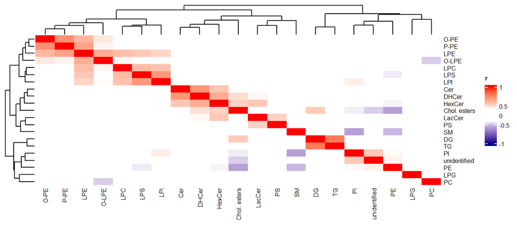

```r
sort_hclust <- function(...) as.hclust(dendsort(as.dendrogram(...)))
cluster_cols <- sort_hclust(hclust(dist(class_average_correlations)))

# Color all low correlations between -0.35 and +0.35 white
color_steps <- 40

color_correlations <- colorRamp2(
  c(-1, -0.35, 0.35, 1),
  c("darkblue", "white", "white", "red")
)

figure_2a <- Heatmap(
  matrix = class_average_correlations,
  col = color_correlations,
  cluster_rows = cluster_cols,
  cluster_columns = cluster_cols,
  heatmap_legend_param = list(
    col_fun = color_correlations,
    title = "r",
    at = c(-1, -0.5, 0, 0.5, 1),
    break_dist = c(1, 0.5, 0.5, 1)
  ),
  width = 1
)
# plot within cowplot
figure_2a <- plot_grid(grid.grabExpr(draw(figure_2a)))
figure_2a
```

#### Figure 2B-F

Custom PCA plot function, based on the normalization manuscript: Leegwater et al. 2025.

```r
get_pca_df <- function(pca_obj, metadata) {
  df <- data.frame(pca_obj$variates$X) %>%
    rownames_to_column("group") %>%
    left_join(metadata, by = "group")
  return(df)
}
plot_PCA_df <- function(pca_obj, metadata, color_metadata, legend = F,
                        components = c("PC1", "PC2")) {
  PC1_var <- round(pca_obj$prop_expl_var$X[[components[1]]], 2) * 100
  x_label <- str_glue("{components[1]} ({PC1_var}% expl. var)")
  PC2_var <- round(pca_obj$prop_expl_var$X[[components[2]]], 2) * 100
  y_label <- str_glue("{components[2]} ({PC2_var}% expl. var)")

  df <- get_pca_df(pca_obj, metadata) %>%
    arrange(.data[[color_metadata]])

  p <- ggplot(df, aes(
    x = .data[[components[1]]], y = .data[[components[2]]],
    color = .data[[color_metadata]]
  )) +
    labs(x = x_label, y = y_label) +
    theme(legend.position = ifelse(legend, "bottom", "none"))

  if (color_metadata %in% c("Morphology", "Morphology_short", "Subtype")) {
    p <- p + geom_point() +
      scale_color_manual(values = color_legend_cell_lines)
  } else if (color_metadata %in% c("ProliferationRate")) {
    p <- p + geom_point()
  } else {
    p <- p + geom_point()
  }
  return(p)
}

forest_plot_loadings <- function(PC_name, highlight = c(), prop_expl_var = NA) {
  y_limits <- max(abs(PCA_loadings[[PC_name]]))
  if (is.na(prop_expl_var)) {
    prop_expl_var <- pca_lipid_classes$prop_expl_var$X[[PC_name]]
  }
  class_order <- lipid_categories$lipid_class
  PCA_loadings %>%
    left_join(lipid_categories, by = "lipid_class") %>%
    mutate(lipid_class = factor(lipid_class, levels = class_order)) %>%
    ggplot(aes(x = lipid_class, y = .data[[PC_name]])) +
    geom_point() +
    scale_x_discrete(guide = guide_axis(angle = 90)) +
    scale_y_continuous(limits = c(-y_limits, y_limits)) +
    geom_hline(yintercept = 0, linetype = "dashed") +
    labs(x = NULL, y = str_glue("{PC_name} ({round(prop_expl_var, 2)*100}%)")) ->
  p

  # Highlight specific lipid classes
  if (length(highlight) > 0 & is.character(highlight)) {
    p <- p +
      aes(
        color = ifelse(lipid_class %in% highlight, "highlight", "other"),
        shape = ifelse(lipid_class %in% highlight, "highlight", "other")
      ) +
      scale_color_manual(values = c("other" = "darkgrey", "highlight" = "black")) +
      scale_shape_manual(values = c("other" = 16, "highlight" = 17)) +
      theme(legend.position = "none")
  }
  # Highlight everything above a certain limit
  if (length(highlight) > 0 & is.numeric(highlight)) {
    p <- p +
      aes(
        color = ifelse(abs(.data[[PC_name]]) > highlight, "highlight", "other"),
        shape = ifelse(abs(.data[[PC_name]]) > highlight, "highlight", "other")
      ) +
      scale_color_manual(values = c("other" = "darkgrey", "highlight" = "black")) +
      scale_shape_manual(values = c("other" = 16, "highlight" = 17)) +
      theme(legend.position = "none")
  }
  return(p)
}
```

#### Load data

```r
heatmap_metadata_data <- read_csv(here(data_dir, "heatmap_metadata_data.csv")) %>%
  replace_na(list(category = "")) %>%
  column_to_rownames("metadata_name")
PCA_loadings <- read_csv(here(data_dir, "PCA_loadings_lipid_classes.csv")) %>%
  mutate(lipid_class = ifelse(lipid_class == "unidentified sphingolipid", "unidentified", lipid_class))
load(here(data_dir, "pca_lipid_classes.RData"))
```

#### Plot

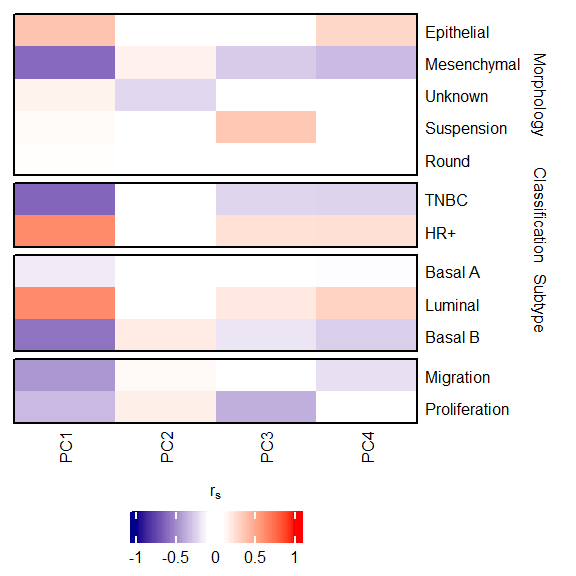

```r
colors_heatmap <- circlize::colorRamp2(c(-1, -0.1, 0, 0.1, 1), c("darkblue", "white", "white", "white", "red"))

categories <- heatmap_metadata_data %>%
  select(category) %>%
  mutate(category = factor(category, levels = c("Morphology", "Classification", "Subtype", "")))

heatmap_metadata_data <- select(heatmap_metadata_data, -category)

figure_2c <- draw(
  Heatmap(heatmap_metadata_data,
    col = colors_heatmap,
    cluster_rows = F,
    cluster_columns = F,
    row_split = categories$category,
    row_title_side = "right",
    row_title_gp = gpar(fontsize = text_size),
    heatmap_legend_param = list(
      title = expression(r[s]),
      direction = "horizontal",
      title_position = "topcenter"
    ),
    border = TRUE
  ),
  heatmap_legend_side = "bottom"
)
```

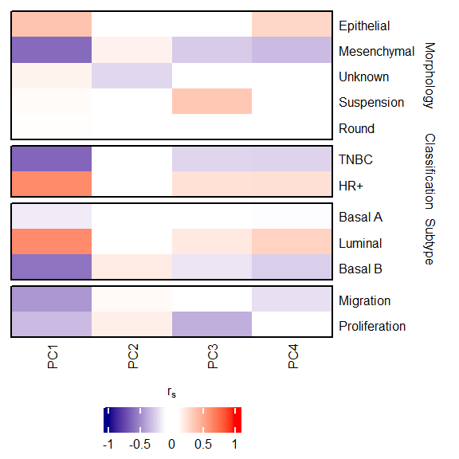

```r
figure_2c <- plot_grid(grid.grabExpr(draw(figure_2c)))
figure_2c
```

#### Heatmap for lipid classes

Prepare metadata on cell lines for the heatmap

```r
metadata %>%
  dplyr::select(group, Morphology, Subtype, EMT_score) %>%
  filter(group %in% lipid_class_averages$cell_line) %>%
  column_to_rownames("group") -> metadata_heatmap_cells
dim(metadata_heatmap_cells)
```

```
[1] 52  3
```

```r
head(metadata_heatmap_cells)
```

|  | Morphology | Subtype | EMT_score |
| --- | --- | --- | --- |
| BT20 | Epithelial-like | BasalA | -1.33 |
| BT483 | Epithelial-like | Luminal | -3.22 |
| BT549 | Mesenchymal-like | BasalB | 10.60 |
| CAMA-1 | Unknown | Luminal | -2.74 |
| DU4475 | Suspension | BasalA | -0.36 |
| EVSA-T | Epithelial-like | Luminal | -3.45 |

```r
# sort the columns to match the metadata column order
df_heatmap <- lipid_class_averages %>%
  pivot_longer(!cell_line, names_to = "class", values_to = "value") %>%
  pivot_wider(id_cols = class, names_from = cell_line, values_from = value) %>%
  column_to_rownames("class") %>%
  dplyr::select(all_of(rownames(metadata_heatmap_cells)))
stopifnot(all(rownames(metadata_heatmap_cells) == colnames(df_heatmap)))
```

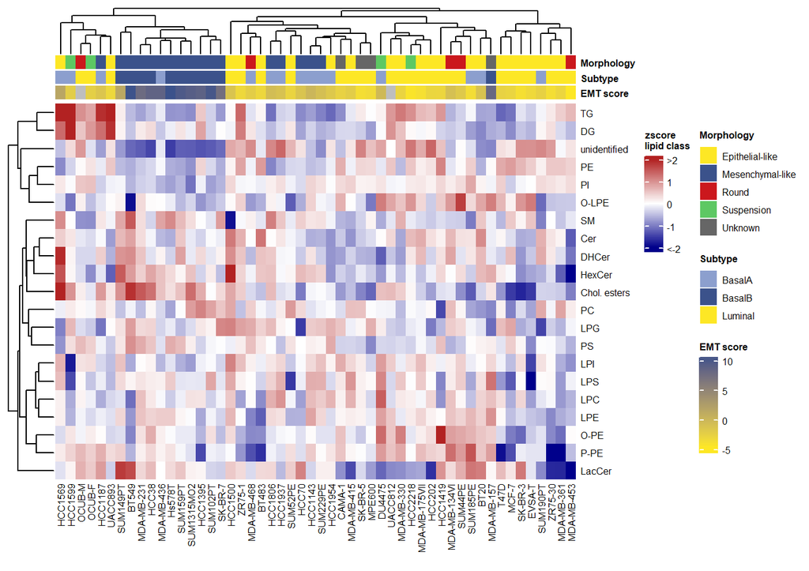

```r
column_annotation <- columnAnnotation(
  Morphology = metadata_heatmap_cells$Morphology,
  Subtype = metadata_heatmap_cells$Subtype,
  "EMT score" = metadata_heatmap_cells$EMT_score,
  col = ann_colors,
  simple_anno_size = unit(3, "mm")
)

#  lipid_class_averages
figure_2f <- grid.grabExpr(draw(
  Heatmap(
    matrix = df_heatmap,
    col = color_heatmap,
    heatmap_legend_param = list(
      title = "zscore\nlipid class",
      direction = "vertical",
      title_gp = grid::gpar(fontsize = text_size, fontface = 2),
      labels_gp = grid::gpar(fontsize = text_size),
      legend_width = unit(6, "cm"),
      at = c(-2, -1, 0, 1, 2),
      labels = c("<-2", -1, 0, 1, ">2"),
      break_dist = c(1, 1, 1, 1)
    ),
    top_annotation = column_annotation,
  )
))
plot_grid(figure_2f)
```

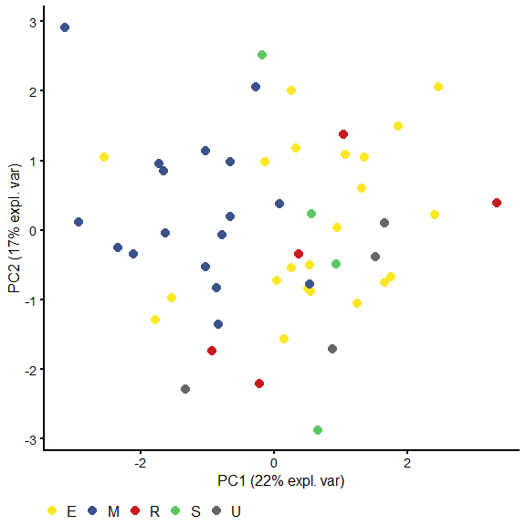

```r
figure_2b <- plot_PCA_df(
  pca_lipid_classes, metadata,
  legend = T, color_metadata = "Morphology_short"
) +
  labs(color = NULL)
figure_2b
```

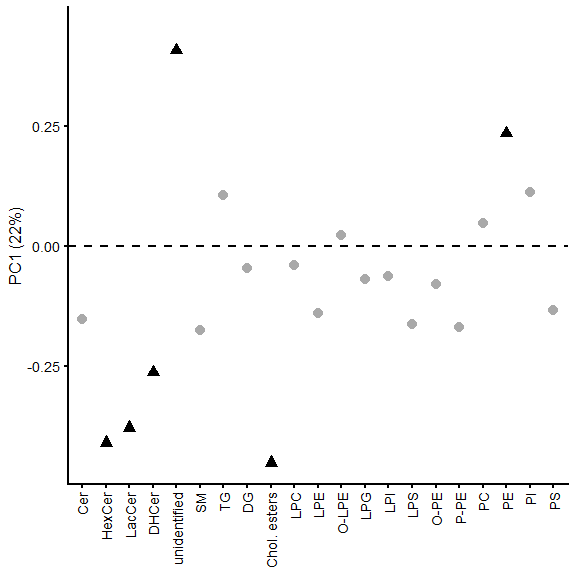

```r
figure_2d <- forest_plot_loadings("PC1", highlight = 0.2)
figure_2e <- forest_plot_loadings("PC2", highlight = 0.2)
figure_2d
```

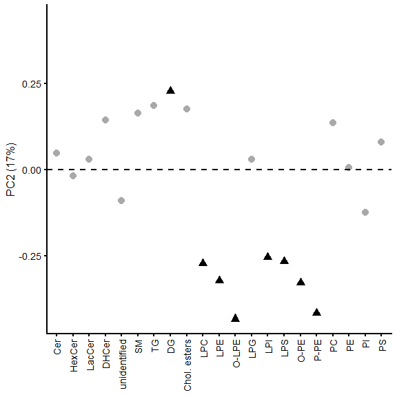

```r
figure_2e
```

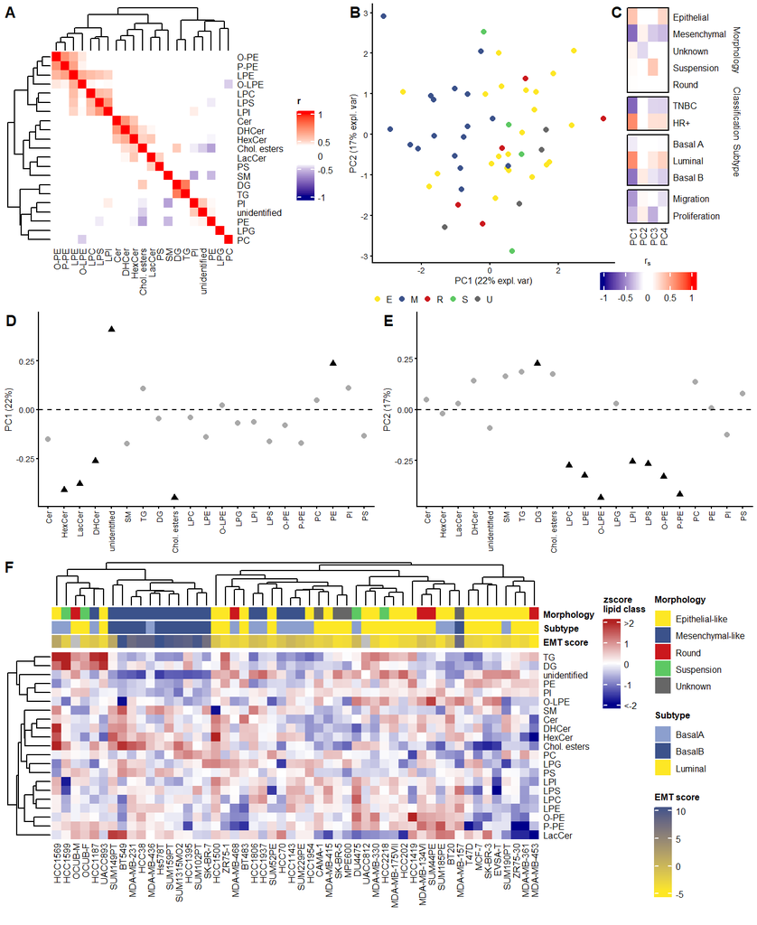

```r
figure_2 <- plot_grid(
  # ABCDE
  #plot_grid(
    # ABC
    plot_grid(
      plot_grid(
        figure_2a,
        figure_2b,
        figure_2c,
        labels = LETTERS[1:3],
        rel_widths = c(5, 4,2),
        nrow = 1,
        label_x = c(0, 0, - 0.1) # Adjust label plot C
      ),
      # DE
      plot_grid(
        figure_2d,
        figure_2e,
        labels = LETTERS[4:5]
      ),
      nrow = 2,
      rel_heights = c(5, 4)
    #),
  ),
  # F
  plot_grid(figure_2f,
    labels = LETTERS[6]
  ),
  ncol = 1,
  rel_heights = c(3, 2)
)
figure_2
```

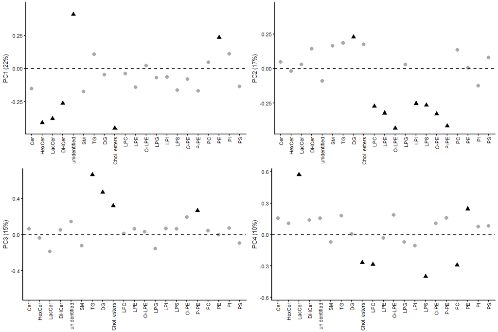

```r
# Show other PCs in report
plot_grid(
  forest_plot_loadings("PC1", highlight = 0.2),
  forest_plot_loadings("PC2", highlight = 0.2),
  forest_plot_loadings("PC3", highlight = 0.2),
  forest_plot_loadings("PC4", highlight = 0.2)
)
```

#### Save figure

```r
save_as_png_svg_pdf("Figure_2", figure_2, base_height = 22)
```

```
[1] "C:/Users/leegwaterh/surfdrive/Investigations/Lipidomics/manuscript_biology/revision_figures_v20250723/Figure_2.tiff"
```

### Figure 3

#### Load data

```r
lipid_class_averages_long <- read_csv(here(data_dir, "lipid_class_averages_long_after_SL_normalization.csv")) %>%
  mutate(subclass = ifelse(subclass == "unidentified sphingolipid", "unidentified", subclass))
anova_info_lipid_class <- read_csv(here(data_dir, "anova_results_lipid_class_and_Subtype.csv")) %>%
  mutate(subclass = ifelse(subclass == "unidentified sphingolipid", "unidentified", subclass)) %>%
  column_to_rownames("subclass")
```

#### Define functions

```r
abbreviate_subtype <- function(subtype) {
  if (subtype == "Luminal") {
    return("L")
  }
  if (subtype == "BasalA") {
    return("Ba")
  }
  if (subtype == "BasalB") {
    return("Bb")
  }
  stop("Something wrong with subtype")
}
```

```r
calculate_significance_anova <- function(df_subclass, subclass_name, verbose = T, use_group_nr = F) {
  # calculate whether there is a difference between the three subgroups
  # Value: the pvalue from the anova and the aov object

  # the anova is here calculated but not used, because I want to use the multiple-testing-corrected anovas from the previous code chunk
  if (use_group_nr) {
    df_subclass <- mutate(df_subclass, group_nr = factor(as.numeric(Subtype)))
    result <- lm(subclass_mean ~ group_nr, data = df_subclass)
  } else {
    result <- lm(subclass_mean ~ Subtype, data = df_subclass)
  }
  result_anova <- anova(result)
  result_aov <- aov(result)
  padj_anova <- anova_info_lipid_class[subclass_name, "padj"]

  if (verbose) {
    print(str_glue("{subclass_name} Anova result Pr(>F) with BH multiple testing correction is {padj_anova}"))
  }

  return(list(pvalue_anova = padj_anova, result_aov = result_aov))
}
```

```r
get_significance_letters <- function(significance_anova, df_subclass, use_group_nr = F) {
  # calculate which groups are different using the TukeyHSD function on an aov object
  # Value: the letters. different letters mean a significant difference between the groups

  if (significance_anova$pvalue_anova > 0.05) {
    # No significant difference, so all three groups get the same letter
    significance_letters <- data.frame(
      "Subtype" = levels(df_subclass$Subtype),
      "Letters" = rep("a", length(levels(df_subclass$Subtype)))
    )
  } else {
    # so there is a difference. Now, which ones are different?
    significance_levels <- TukeyHSD(significance_anova$result_aov)
    significance_letters <- multcompLetters(significance_levels[[1]][, "p adj"], threshold = 0.05)
    significance_letters <- data.frame(Letters = significance_letters$Letters) %>%
      rownames_to_column("Subtype")
    if (use_group_nr) {
      significance_letters %>%
        rename(group_nr = Subtype) %>%
        left_join(
          data.frame(
            group_nr = c("1", "2", "3"),
            Subtype = c("L", "Ba", "Bb")
          ),
          by = "group_nr"
        ) %>%
        select(-group_nr) -> significance_letters
    }
  }
  # Prepare to put on plot. For this, find the max subclass value per group and put the letter a bit above that
  # And sort letters on the order of the factor
  subclass_range <- max(df_subclass$subclass_mean) - min(df_subclass$subclass_mean)
  significance_letters %>%
    mutate(Subtype = factor(Subtype, levels = c("L", "Ba", "Bb"))) %>%
    left_join(
      df_subclass %>%
        group_by(Subtype) %>%
        summarize(y = max(subclass_mean) + 0.1 * subclass_range),
      by = "Subtype"
    ) -> letters_df

  return(letters_df)
}
```

```r
plot_violin_alphabetical <- function(subclass_name, use_full_name = F) {
  # check if there is a difference between groups, add these as letters to groups, and create a violin plot
  # Value: the plot object

  # subset data
  df_subclass <- lipid_class_averages_long %>%
    filter(subclass == subclass_name) %>%
    left_join(
      dplyr::select(metadata, group, Subtype) %>% unique(),
      by = "group"
    ) %>%
    rowwise() %>%
    mutate(Subtype = abbreviate_subtype(Subtype)) %>%
    mutate(Subtype = factor(Subtype, levels = c("L", "Ba", "Bb"))) %>%
    dplyr::select(group, Subtype, subclass_mean)

  # get significance letters
  significance_anova <- calculate_significance_anova(df_subclass, subclass_name, use_group_nr = T)
  letters_df <- get_significance_letters(significance_anova, df_subclass, use_group_nr = T)

  if (use_full_name) {
    df_subclass <- df_subclass %>%
      rowwise() %>%
      mutate(subclass = full_lipid(subclass_name))
  } else {
    df_subclass <- df_subclass %>%
      rowwise() %>%
      mutate(subclass = subclass_name)
  }
  # make plot
  df_subclass %>%
    left_join(letters_df, by = "Subtype") %>%
    arrange(Subtype) %>%
    ggplot(aes(
      x = Subtype, y = subclass_mean,
      fill = Subtype
    )) +
    facet_wrap(~subclass, scales = "free_y", nrow = 2) +
    theme(legend.position = "none") +
    labs(y = "class average", x = NULL) +
    scale_fill_manual(values = color_legend_Subtype) +
    geom_violin(draw_quantiles = 0.5) +
    geom_jitter(aes(alpha = 0.5), width = 0.2, height = 0) +
    geom_text(aes(x = Subtype, y = y, label = Letters), data = letters_df) -> p
  return(p)
}
```

#### Plot

```r
print(colnames(lipid_class_averages))
```

```
 [1] "cell_line"    "Cer"          "Chol. esters" "DG"           "DHCer"
 [6] "HexCer"       "LPC"          "LPE"          "LPG"          "LPI"
[11] "LPS"          "LacCer"       "O-LPE"        "O-PE"         "P-PE"
[16] "PC"           "PE"           "PI"           "PS"           "SM"
[21] "TG"           "unidentified"
```

```r
lipids_to_plot <- c("Chol. esters", "PE", "PI", "unidentified", "SM", "PS")
set.seed(5) # for geom_jitter
lapply(lipids_to_plot, function(x) plot_violin_alphabetical(x)) -> plot_list
```

```
Chol. esters Anova result Pr(>F) with BH multiple testing correction is 0.000230942917281209
PE Anova result Pr(>F) with BH multiple testing correction is 7.14633481747799e-07
PI Anova result Pr(>F) with BH multiple testing correction is 3.38652536075509e-06
unidentified Anova result Pr(>F) with BH multiple testing correction is 1.02972298131269e-08
SM Anova result Pr(>F) with BH multiple testing correction is 0.0100299531641152
PS Anova result Pr(>F) with BH multiple testing correction is 0.0201349891087215
```

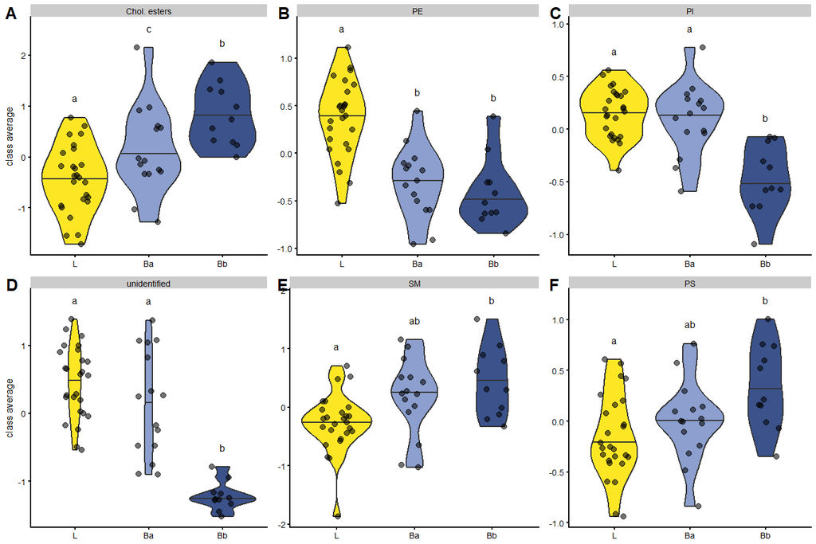

```r
plot_list <- lapply(plot_list, function(p) p <- p + labs(y = NULL))
n_col <- 3
plot_list[seq(1, length(plot_list), by = n_col)] <- lapply(
  plot_list[seq(1, length(plot_list), by = n_col)],
  function(p) p <- p + labs(y = "class average")
)
figure_3 <- plot_grid(
  plotlist = plot_list,
  ncol = n_col,
  labels = LETTERS[1:length(plot_list)]
)
figure_3
```

#### Save plot

```r
save_as_png_svg_pdf(figure_3, figure_name = "Figure_3", base_height = 2 / 3 * page_width)
```

```
[1] "C:/Users/leegwaterh/surfdrive/Investigations/Lipidomics/manuscript_biology/revision_figures_v20250723/Figure_3.tiff"
```

And a bit smaller for better relative font sizes

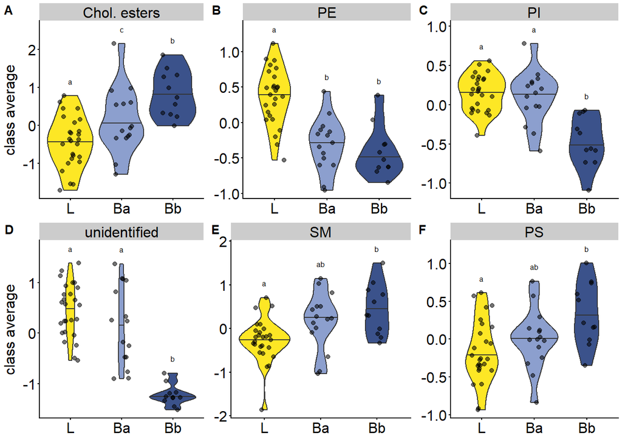

```r
plot_list_smaller <- lapply(plot_list, function(p) p +
                      theme(
                        axis.text.x = element_text(size = text_size * 2),
                        axis.text.y = element_text(size = text_size * 2),
                        axis.title.y = element_text(size = text_size * 2),
                        strip.text = element_text(size = text_size * 2)
                      ))
figure_3_smaller <- plot_grid(
  plotlist = plot_list_smaller,
  ncol = n_col,
  labels = LETTERS[1:length(plot_list_smaller)]
)
figure_3_smaller
```

```r
save_as_png_svg_pdf(figure_3_smaller, figure_name = "Figure_3_smaller",
                    base_height = 2 / 3 * page_width)
```

```
[1] "C:/Users/leegwaterh/surfdrive/Investigations/Lipidomics/manuscript_biology/revision_figures_v20250723/Figure_3_smaller.tiff"
```

### Figure 4

Plot design idea is:

- A: fold changes or directed p values epithelial proliferation and mesenchymal proliferation to show similarities and differences
- B: lipids associated with epithelial proliferation per class
- C: PI, PC, PE and PS with colored side chains

#### Load data

```r
E_M_prol_lipids <- read_csv(here(data_dir, "Supplementary_Table_4_lipid_proliferation.csv"))
head(E_M_prol_lipids)
```

| identifiers | subclass | coefficient_prol_M | P.Value_M | adj.P.Val_M | coefficient_prol_E | P.Value_E | adj.P.Val_E | color_FDR | database_identifier |
| --- | --- | --- | --- | --- | --- | --- | --- | --- | --- |
| PS 16:0_18:1 | PS | 1.1188277 | 0.0001416 | 0.1051654 | 1.2691698 | 0.0040191 | 0.0765191 | sig pos | SLM:000077765 |
| PS 16:1_18:1 | PS | 1.2334015 | 0.0003463 | 0.1051654 | 1.4804294 | 0.0046218 | 0.0765191 | sig pos | SLM:000077818 |
| PS 18:1_18:2 | PS | 0.8077129 | 0.0003914 | 0.1051654 | 0.9604258 | 0.0054096 | 0.0765191 | sig pos | SLM:000078021 |
| PS 16:0_16:0 | PS | 1.2514216 | 0.0005979 | 0.1204769 | 1.2564017 | 0.0214484 | 0.1280551 | almost sig pos | SLM:000077760 |
| PS 16:0_16:1 | PS | 1.4657157 | 0.0009446 | 0.1389392 | 1.5285215 | 0.0221279 | 0.1293766 | almost sig pos | SLM:000077761 |
| PS 16:0_18:2 | PS | 1.1285928 | 0.0010343 | 0.1389392 | 0.6529631 | 0.1971235 | 0.3414678 | not sig | SLM:000077766 |

#### 4A cor E and M proliferation

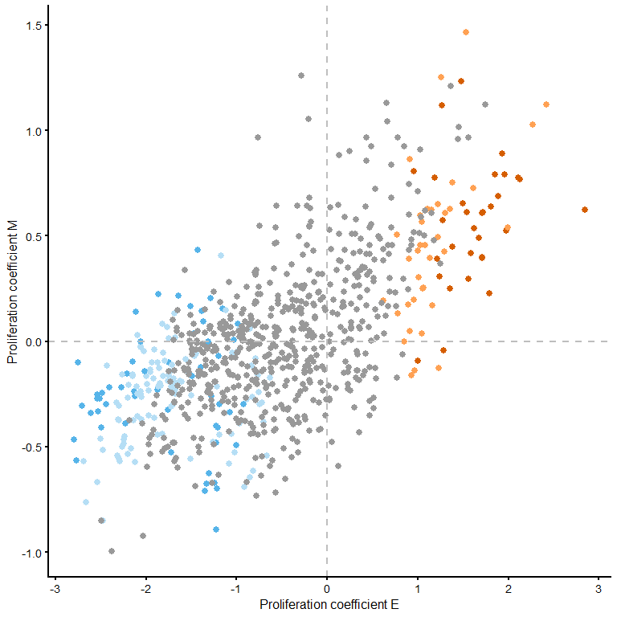

```r
use_FDR <- T
sig_cutoff <- 0.1

E_M_prol_lipids %>%
  ggplot(aes(x = coefficient_prol_E, y = coefficient_prol_M, color = color_FDR)) +
  geom_point(size = 1) +
  geom_hline(yintercept = 0, linetype = "dashed", color = "grey") +
  geom_vline(xintercept = 0, linetype = "dashed", color = "grey") +
  scale_color_manual(
    values = c(
      "not sig" = "#999999", "sig neg" = "#56B4E9", "sig pos" = "#D55E00",
      "almost sig neg" = "#B5DEF5", "almost sig pos" = "#FFA153"
    ),
    name = NULL,
    labels = c(
      "not sig" = "Not significant",
      "sig neg" = str_glue("Neg. FDR < {sig_cutoff}"),
      "sig pos" = str_glue("Pos. FDR < {sig_cutoff}"),
      "almost sig neg" = str_glue("Neg. p < {sig_cutoff}"),
      "almost sig pos" = str_glue("Pos. p < {sig_cutoff}")
    )
  ) +
  labs(x = "Proliferation coefficient E", y = "Proliferation coefficient M") ->
figure_4a
figure_4a
```

#### 4B Forest plot

##### Define forest plot for Figure 4 and 6

Code based on: Holbaek_lipidomic.Rmd

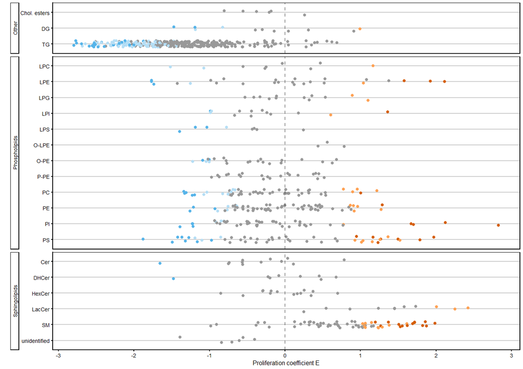

```r
forest_plot <- function(df_lipids, x_label, use_FDR = T, sig_cutoff = 0.1, logFC_column = "logFC") {
  df_lipids <- df_lipids %>%
    mutate(subclass = ifelse(subclass == "unidentified sphingolipid", "unidentified", subclass)) %>%
    left_join(lipid_categories, by = c("subclass" = "lipid_class"))

  df_lipids <- df_lipids %>%
    dplyr::rename(
      FDR = ifelse(use_FDR, "adj.P.Val", "P.Value"),
      coefficient = logFC_column
    )

  forest_class <- df_lipids %>%
    ggplot(aes(x = coefficient, y = subclass)) +
    geom_point(aes(color = color_FDR),
      position = position_jitter(width = 0.02, height = 0.2),
      size = 1 # size = 0.3
    ) +
    scale_color_manual(
      values = color_legend_significance,
      name = NULL,
      labels = c(
        "not sig" = "Not significant",
        "sig neg" = ifelse(use_FDR, str_glue("Neg. FDR < {sig_cutoff}"), str_glue("Neg. p < {sig_cutoff}")),
        "sig pos" = ifelse(use_FDR, str_glue("Pos. FDR < {sig_cutoff}"), str_glue("Pos. p < {sig_cutoff}")),
        "almost sig neg" = "Neg. p < 0.05", "almost sig pos" = "Pos. p < 0.05"
      )
    ) +
    scale_y_discrete(limits = rev) +
    labs(y = "", x = x_label) +
    geom_vline(
      xintercept = 0,
      color = "black",
      linetype = "dashed",
      alpha = .4
    ) +
    theme(strip.placement = "outside") +
    theme(
      panel.grid.major.y = element_line(color = "grey80"),
      panel.grid.minor.y = element_line(color = "grey80"),
      panel.border = element_rect(colour = "black", size = 0.4),
      strip.background.y = element_rect(
        colour = "black",
        fill = "white",
        size = 0.4
      )
    ) +
    facet_grid(
      rows = vars(lipid_category),
      scales = "free",
      space = "free",
      switch = "y"
    )

  return(forest_class)
}

set.seed(5) # for geom_jitter
E_M_prol_lipids %>%
  dplyr::rename(adj.P.Val = adj.P.Val_E, P.Value = P.Value_E) %>%
  forest_plot("Proliferation coefficient E", use_FDR, sig_cutoff,
    logFC_column = "coefficient_prol_E"
  ) ->
figure_4b
figure_4b
```

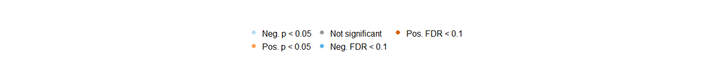

```r
legend_figure_4b <- get_legend(figure_4b, "bottom", n_row = 2)
ggdraw(legend_figure_4b)
```

#### 4C

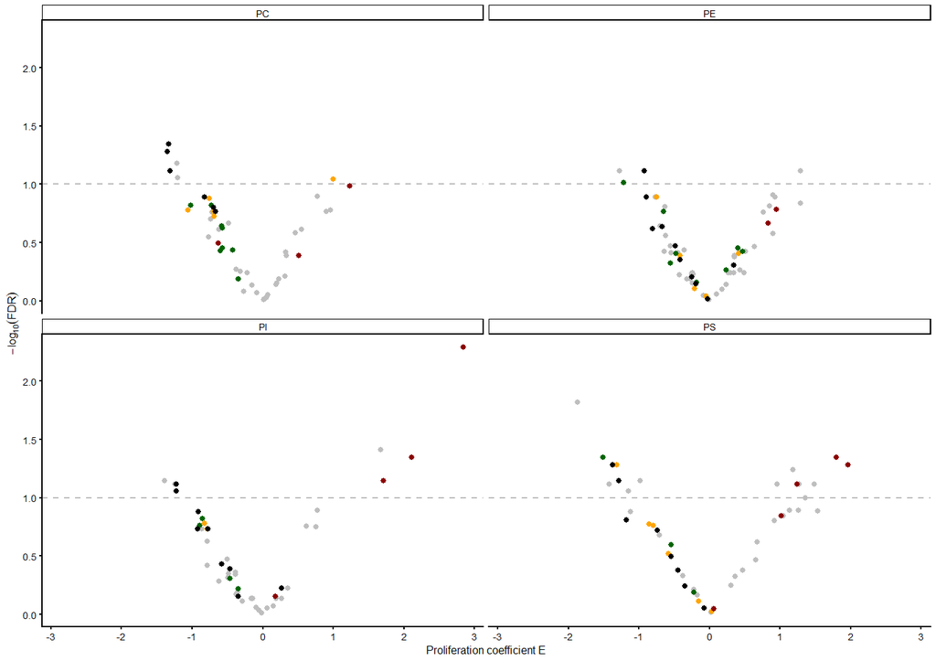

```r
phospholipids_plot <- function(df_coefficients, coefficient, x_label) {
  df_coefficients %>%
    filter(subclass %in% c("PC", "PS", "PE", "PI")) %>%
    left_join(lipid_categories, by = c("subclass" = "lipid_class")) %>%
    dplyr::rename(FDR = ifelse(use_FDR, "adj.P.Val", "P.Value"), coefficient = all_of(coefficient)) %>%
    mutate(to_color = ifelse(!subclass %in% names(color_legend_side_chains) & str_detect(identifiers, "20:3"), "20:3", "nocolor")) %>%
    mutate(to_color = ifelse(!subclass %in% names(color_legend_side_chains) & str_detect(identifiers, "20:4"), "20:4", to_color)) %>%
    mutate(to_color = ifelse(!subclass %in% names(color_legend_side_chains) & str_detect(identifiers, "17:0"), "17:0", to_color)) %>%
    mutate(to_color = ifelse(!subclass %in% names(color_legend_side_chains) & str_detect(identifiers, "20:1"), "20:1", to_color)) %>%
    mutate(to_color = factor(to_color, levels = names(color_legend_side_chains))) %>%
    arrange(to_color) -> df_for_plot
  x_max <- max(abs(df_for_plot$coefficient))

  p <-
    df_for_plot %>%
    ggplot(aes(x = coefficient, y = -log10(FDR), color = to_color, label = identifiers)) +
    geom_hline(yintercept = -log10(sig_cutoff), linetype = "dashed", color = "grey") +
    geom_point(size = 1) +
    theme(
      strip.background.x = element_rect(
        colour = "black",
        fill = "white",
        size = 0.4
      )
    ) +
    labs(
      x = x_label,
      y = ifelse(use_FDR, expression(-log[10](FDR)), expression(-log[10](p.value))),
      color = "FA",
    ) +
    scale_x_continuous(limits = c(-x_max, x_max)) +
    scale_color_manual(
      values = color_legend_side_chains,
      breaks = setdiff(unique(df_for_plot$to_color), "nocolor")
    ) +
    facet_wrap(~subclass, ncol = 2)
  return(p)
}

figure_4c <- E_M_prol_lipids %>%
  dplyr::rename(identifiers = identifiers, adj.P.Val = adj.P.Val_E) %>%
  phospholipids_plot(
    coefficient = "coefficient_prol_E",
    x_label = "Proliferation coefficient E"
  )
figure_4c
```

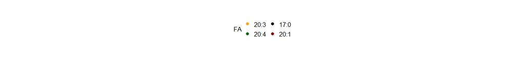

```r
legend_figure_4c <- get_legend(figure_4c, "bottom", n_row = 2)
ggdraw(legend_figure_4c)
```